# Data Exploration

Data Exploration of ‘WRN helicase is a synthetic lethal target in microsatellite unstable cancers’

Martin Brand

November 30, 2022

```r
library(ggplot2)
library(readxl)
library(patchwork)
library(tidyverse)
library(caret)
library(reshape2)
library(ggpubr)
library(ggrepel)

source('C:/Users/Martin/Documents/Master/Forschungspraktikum/data_exploration/WRN_manuscript-master/src/WRN_helpers.R')
```

## Preprocessing of the Data

We import the data provided by the authors as “Supplementary Table 1” and load it into a dataframe. The dataset contains among others the MSI/MSS classifications. Additionally, we import the “DepMap_18Q4_data.rds” dataset, which contains all dependency scores.

```r
# suppress warning message caused by NA values
data_dir <- "C:/Users/Martin/Documents/Master/Forschungspraktikum/data_exploration/data/"
# read file with MSS/MSI classifications
data_suppl <- read_excel(paste0(data_dir, "supplementary_table.xlsx"))
# transform "NA" strings to na values
data_suppl[data_suppl=="NA"] <- NA
# transform numbers saved as strings to numbers
data_suppl <- transform(data_suppl, DRIVE_WRN_D2=as.numeric(DRIVE_WRN_D2), CRISPR_WRN_CERES = as.numeric(CRISPR_WRN_CERES), avg_WRN_dep=as.numeric(avg_WRN_dep))
# delete rows which appear neither in Achilles nor in DRIVE dataset
data_suppl <- data_suppl[!is.na(data_suppl$DRIVE_WRN_D2) | !is.na(data_suppl$CRISPR_WRN_CERES), ]
# delete rows which are classified as intermediate
data_suppl <- data_suppl[data_suppl$CCLE_MSI!="indeterminate", ]
# delete rows which are NA in classification
data_suppl <- data_suppl[!is.na(data_suppl$CCLE_MSI), ]
# read file with dependency scores
data_18Q4 <- read_rds(file.path(data_dir, 'DepMap_18Q4_data.rds'))
dep_scores_18Q4_drive <- data_18Q4[["DRIVE"]]
dep_scores_18Q4_achilles <- data_18Q4[["CRISPR"]]
```

## Visualization of Classifications

We visualize the ratio of cell lines classified as MSS cell and cell lines classified as MSI cells for both Achilles and DRIVE datasets together and separately. We see that the number of MSS cell lines is much higher than the number of MSI cell lines.

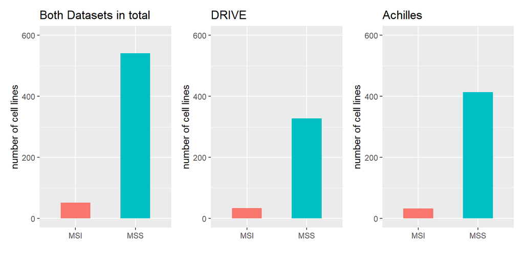

```r
# count rows of MSI and MSS classified cell lines
counts_class <- data.frame(table(data_suppl$CCLE_MSI))

# count rows of MSI and MSS classified cell lines for each dataset separately
counts_class_drive <- data.frame(table(data_suppl[!is.na(data_suppl$DRIVE_WRN_D2),]$CCLE_MSI))
counts_class_achilles <- data.frame(table(data_suppl[!is.na(data_suppl$CRISPR_WRN_CERES),]$CCLE_MSI))

# create plots
# define limits on y axis
limits <- c(0,600)

bar_chart_total <- ggplot(data=counts_class, aes(x=Var1, y=Freq, fill=Var1)) +
  theme(legend.position = "none") +
  geom_bar(stat = "identity", width = 0.5) +
  ggtitle("Both Datasets in total") +
  labs(x="",y="number of cell lines") +
  coord_cartesian(ylim = limits)

bar_chart_drive <- ggplot(data=counts_class_drive, aes(x=Var1, y=Freq, fill=Var1)) +
  theme(legend.position = "none") +
  geom_bar(stat = "identity", width = 0.5) +
  ggtitle("DRIVE") +
  labs(x="",y="number of cell lines") +
  coord_cartesian(ylim = limits)

bar_chart_achilles <- ggplot(data=counts_class_achilles, aes(x=Var1, y=Freq, fill=Var1)) +
  theme(legend.position = "none") +
  geom_bar(stat = "identity", width = 0.5) +
  ggtitle("Achilles") +
  labs(x="",y="number of cell lines") +
  coord_cartesian(ylim = limits)

bar_chart_total + bar_chart_drive + bar_chart_achilles
```

## Correlation of Achilles and DRIVE dataset

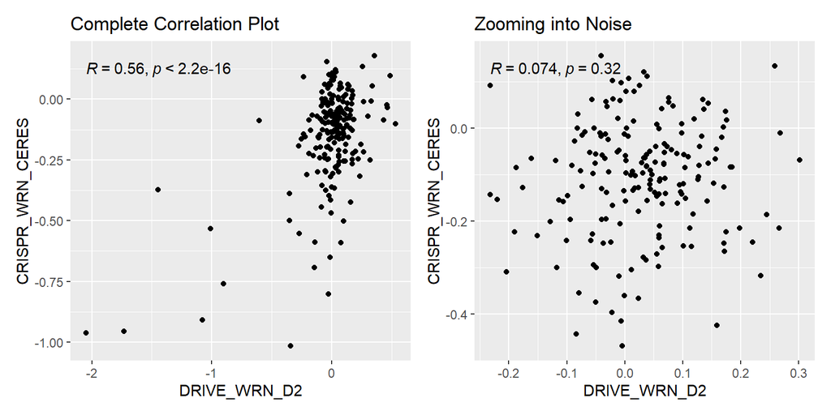

```r
# extract dependency scores
dep_scores <- data_suppl %>% select(5,6)
# remove rows with na
dep_scores <- na.omit(dep_scores)

# remove outliers
outliers_achilles <- boxplot(dep_scores$CRISPR_WRN_CERES, plot=FALSE)$out
cleaned_dep_scores<- dep_scores[-which(dep_scores$CRISPR_WRN_CERES %in% outliers_achilles),]
outliers_drive <- boxplot(cleaned_dep_scores$DRIVE_WRN_D2, plot=FALSE)$out
cleaned_dep_scores<- cleaned_dep_scores[-which(cleaned_dep_scores$DRIVE_WRN_D2 %in% outliers_drive),]
# create scatter plot with and without outliers
corr_plot <- ggplot(dep_scores, aes(x=DRIVE_WRN_D2, y=CRISPR_WRN_CERES)) +
  geom_point() + stat_cor() +
  ggtitle('Complete Correlation Plot')
cleaned_corr_plot <- ggplot(cleaned_dep_scores, aes(x=DRIVE_WRN_D2, y=CRISPR_WRN_CERES)) +
  geom_point() + stat_cor() +
  ggtitle('Zooming into Noise')
corr_plot + cleaned_corr_plot
```

## Histograms

We visualize the the difference between the dependency scores for MSS and MSI cells as histograms.

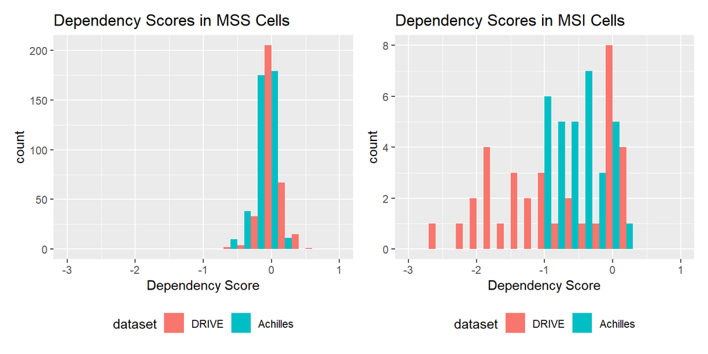

```r
# create MSI/MSS specific subsets with dependency scores
dep_scores <- data_suppl %>% select(1,4,5,6)
colnames(dep_scores) <- c("CCLE_ID", "CCLE_MSI", "DRIVE", "Achilles")
dep_scores <- melt(data = dep_scores, id.vars = c("CCLE_ID","CCLE_MSI"))
colnames(dep_scores) <- c("CCLE_ID", "CCLE_MSI", "dataset", "dep_score")
dep_scores <- dep_scores[!is.na(dep_scores$dep_score),]
dep_scores_mss <- data.frame(dep_scores[dep_scores$CCLE_MSI=="MSS",])
dep_scores_msi <- data.frame(dep_scores[dep_scores$CCLE_MSI=="MSI",])

# create plots for MSS and MSI cells separately
limits <- c(-3,1) # add limits in x axis

plot_mss <- ggplot(data = dep_scores_mss, aes(x=dep_score, fill=dataset)) +
  geom_histogram(binwidth = 0.2, position = "dodge") +
  coord_cartesian(xlim = limits) +
  xlab("Dependency Score") +
  ggtitle("Dependency Scores in MSS Cells") +
  theme(legend.position="bottom")

plot_msi <- ggplot(data = dep_scores_msi, aes(x=dep_score, fill=dataset)) +
  geom_histogram(binwidth = 0.2, position = "dodge") +
  coord_cartesian(xlim = limits) +
  xlab("Dependency Score") +
  ggtitle("Dependency Scores in MSI Cells") +
  theme(legend.position="bottom")

plot_mss + plot_msi
```

```r
# the offset is different in DRIVE and Achilles... why?
```

## Density Plots

We visualize the the difference between the dependency scores for MSS and MSI cells as density plots.

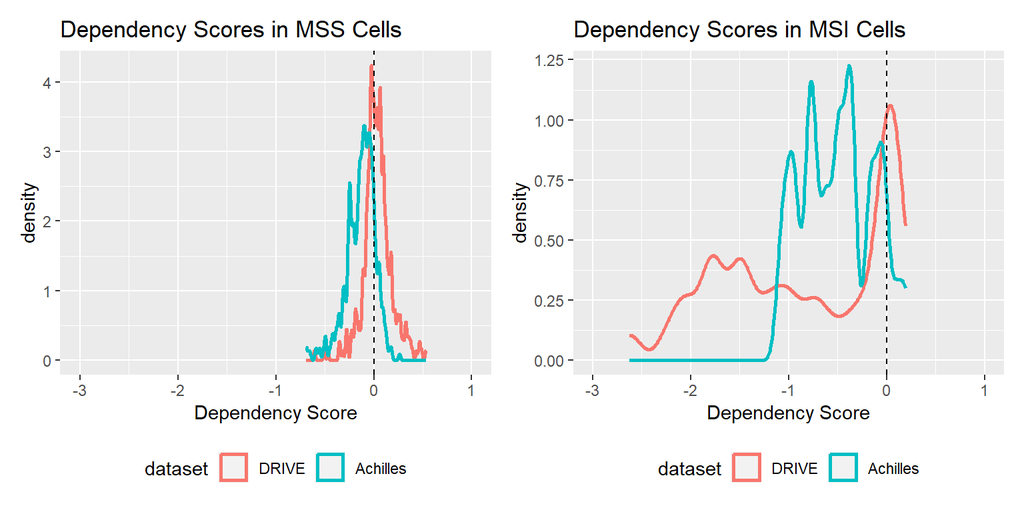

```r
plot_mss <- ggplot(data = dep_scores_mss, aes(x=dep_score, color=dataset)) +
  geom_density(size=1, adjust = 0.3) +
  coord_cartesian(xlim = limits) +
  xlab("Dependency Score") +
  ggtitle("Dependency Scores in MSS Cells") +
  theme(legend.position="bottom") +
  geom_vline(xintercept = 0, linetype=2)
plot_msi <- ggplot(data = dep_scores_msi, aes(x=dep_score, color=dataset)) +
  geom_density(size=1, adjust = 0.3) +
  coord_cartesian(xlim = limits) +
  xlab("Dependency Score") +
  ggtitle("Dependency Scores in MSI Cells") +
  theme(legend.position="bottom") +
  geom_vline(xintercept = 0, linetype=2)

plot_mss + plot_msi
```

## Box Plots

We visualize the the difference between the dependency scores for MSS and MSI cells as box plots.

```r
# extract DRIVE and Achilles data separately with classifications
dep_scores_drive_with_class <- na.omit(data_suppl %>% select(4,5))
dep_scores_achilles_with_class <- na.omit(data_suppl %>% select(4,6))

my_comparisons <- list(c("MSI","MSS"))

box_plot_drive <- ggplot(dep_scores_drive_with_class, aes(x = CCLE_MSI, y = DRIVE_WRN_D2, fill = CCLE_MSI)) +
  geom_violin() +
  ggtitle("Boxplot for DRIVE") +
  theme(legend.position = "none") +
  geom_boxplot(outlier.shape = NA, show.legend = F,width = 0.2, position = position_dodge(width = 0.9)) +
  stat_compare_means(comparisons = my_comparisons, method = "t.test")
```

```
## [1] FALSE
```

```r
box_plot_achilles <- ggplot(dep_scores_achilles_with_class, aes(x = CCLE_MSI, y = CRISPR_WRN_CERES, fill = CCLE_MSI)) +
  theme(legend.position = "none") +
  geom_violin() +
  ggtitle("Boxplot for Achilles") +
  geom_boxplot(outlier.shape = NA, show.legend = F,width = 0.2, position = position_dodge(width = 0.9)) +
  stat_compare_means(comparisons = my_comparisons, method = "t.test")
```

```
## [1] FALSE
```

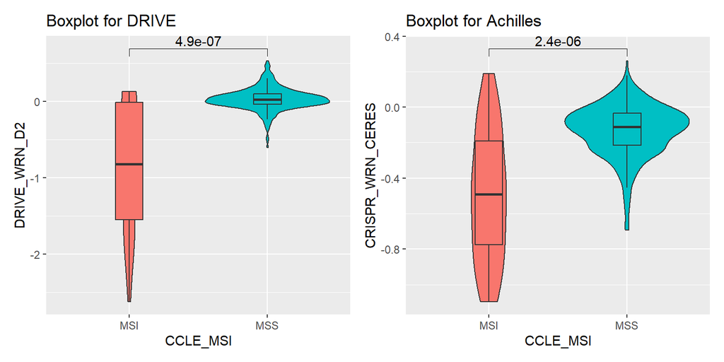

```r
box_plot_drive + box_plot_achilles
```

## Comparing distribution of randomly picked KD/KO genes in Achilles dataset

For comparison we plot the distribution of randomly picked KO/KD genes.

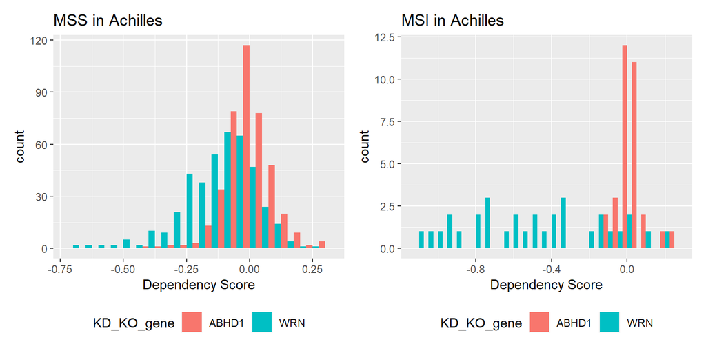

```r
# extract dependency scores for ABHD1
abhd1_dep_scores_achilles <- data.frame(dep_scores_18Q4_achilles[,"ABHD1"])

# format dataset and add column for CCLE_ID
abhd1_dep_scores_achilles$CCLE_ID <- rownames(abhd1_dep_scores_achilles)
colnames(abhd1_dep_scores_achilles) <- c("dep_score_abhd1","CCLE_ID")
rownames(abhd1_dep_scores_achilles) <- c()

# extract subset containing CCLE_IDs, dependency scores and MSI/MSS classifications
dep_scores_achilles <- data_suppl %>% select(1,4,6)

# merge with dependency scores of ABHD1
dep_scores_achilles <- merge(abhd1_dep_scores_achilles, dep_scores_achilles, by="CCLE_ID")
dep_scores_achilles <- dep_scores_achilles[,c(1,3,2,4)]
colnames(dep_scores_achilles) <- c("CCLE_ID","CCLE_MSI","ABHD1", "WRN")

# melt dataset for better plotting
dep_scores_achilles <- melt(data = dep_scores_achilles,id.vars = c("CCLE_ID","CCLE_MSI"))
colnames(dep_scores_achilles) <- c("CCLE_ID","CCLE_MSI","KD_KO_gene", "dep_score")

# remove rows with NAs
dep_scores_achilles <- na.omit(dep_scores_achilles)

# create density plot for MSS cells
plot_mss <- ggplot(data=dep_scores_achilles[dep_scores_achilles$CCLE_MSI=="MSS",],aes(x=dep_score, fill=KD_KO_gene)) +
  geom_histogram(binwidth = 0.05, position = "dodge") +
  ggtitle("MSS in Achilles") +
  xlab("Dependency Score") +
  theme(legend.position="bottom")

# create density plot for MSI cells
plot_msi <- ggplot(data=dep_scores_achilles[dep_scores_achilles$CCLE_MSI=="MSI",],aes(x=dep_score, fill=KD_KO_gene)) +
  geom_histogram(binwidth = 0.05, position = "dodge") +
  ggtitle("MSI in Achilles") +
  xlab("Dependency Score") +
  theme(legend.position="bottom")

# plot results
plot_mss + plot_msi
```

## Comparing p-values of different genes in Achilles dataset

```r
dep_scores_achilles_wrn <- dep_scores_achilles[dep_scores_achilles$KD_KO_gene=="WRN",]
dep_scores_achilles_abhd1 <- dep_scores_achilles[dep_scores_achilles$KD_KO_gene=="ABHD1",]

my_comparisons <- list(c("MSI","MSS"))

box_plot_wrn <- ggplot(dep_scores_achilles_wrn, aes(x = CCLE_MSI, y = dep_score, fill = CCLE_MSI)) +
  geom_violin() +
  ggtitle("Boxplot for WRN") +
  theme(legend.position = "none") +
  geom_boxplot(outlier.shape = NA, show.legend = F,width = 0.2, position = position_dodge(width = 0.9)) +
  stat_compare_means(comparisons = my_comparisons, method = "t.test")
```

```
## [1] FALSE
```

```r
box_plot_abhd1 <- ggplot(dep_scores_achilles_abhd1, aes(x = CCLE_MSI, y = dep_score, fill = CCLE_MSI)) +
  theme(legend.position = "none") +
  geom_violin() +
  ggtitle("Boxplot for ABHD1") +
  geom_boxplot(outlier.shape = NA, show.legend = F,width = 0.2, position = position_dodge(width = 0.9)) +
  stat_compare_means(comparisons = my_comparisons, method = "t.test")
```

```
## [1] FALSE
```

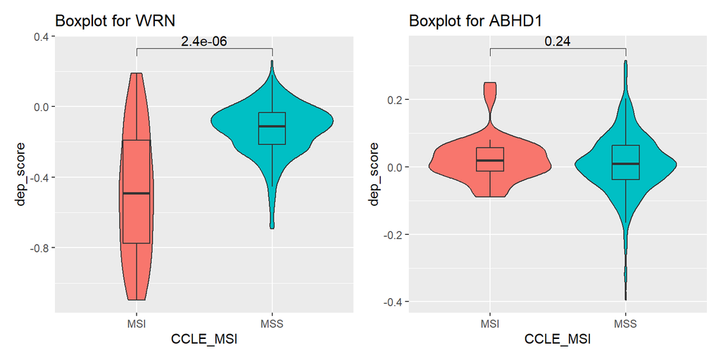

```r
box_plot_wrn + box_plot_abhd1
```

## Calculating means

We calculate the means of MSI and MSS cell lines for every gene and save the result.

```r
mean_dep_scores <- readRDS("mean_dep_scores.rds")
head(mean_dep_scores)
```

```
##      gene             mean_msi            mean_mss
## 1    A1BG   0.0496974608457411  0.0624493177356339
## 2    A1CF   0.0451244172041784  0.0561587374296397
## 3     A2M  -0.0277209451813033 -0.0232659424611942
## 4   A2ML1    0.116222476942142   0.147110661447323
## 5 A3GALT2   -0.027988566511686 -0.0406104199830887
## 6  A4GALT -0.00183055484890335 -0.0239350484172625
```

## Calculating P-Values

We calculate the p-values of MSI and MSS cell lines for every gene and save the result.

```r
p_values <- readRDS("p_values.rds")
# adjust p-values
p_adj <- p_values
p_adj$p_value <- p.adjust(p_values$p_value, method = "hochberg")
head(p_adj)
```

```
##      gene   p_value
## 1    A1BG 0.9997251
## 2    A1CF 0.9997251
## 3     A2M 0.9997251
## 4   A2ML1 0.9997251
## 5 A3GALT2 0.9997251
## 6  A4GALT 0.9997251
```

## Volcano plot

We plot the mean differences of the dependency scores against the corresponding p-values and get a volcano plot.

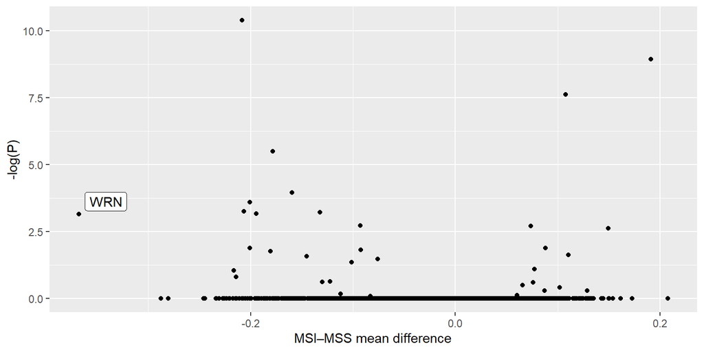

```r
# calculate mean differences of dependency scores
mean_dep_scores$mean_msi <- as.numeric(mean_dep_scores$mean_msi)
mean_dep_scores$mean_mss <- as.numeric(mean_dep_scores$mean_mss)
p_adj$p_value <- as.numeric(p_adj$p_value)
mean_differences <- mean_dep_scores
mean_differences$mean_msi <- NULL
mean_differences$mean_mss <- NULL
mean_differences$difference <- (mean_dep_scores$mean_msi - mean_dep_scores$mean_mss)

# transform p-values
p_values_log <- p_adj
p_values_log$p_value <- NULL
p_values_log$log <- -log(p_adj$p_value)

# create data structure for mean differences and p-values
data <- merge(mean_differences, p_values_log, by="gene")

# define labeled genes
data$to_label <- NA
data$to_label[data$gene == "WRN"] <- "WRN"

ggplot(data=data, aes(x=difference, y=log, label=to_label)) +
  geom_point() +
  xlab('MSI–MSS mean difference') +
  ylab('-log(P)') +
  geom_label_repel()
```

## Using Bayes moderated t-stats

We calculate again the p-values but with Bayes moderated t-stats of the limma package.

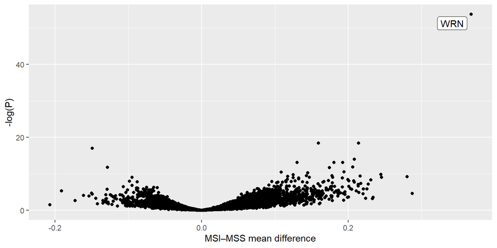

```r
vec <- data_suppl$CCLE_MSI %>% set_names(data_suppl$CCLE_ID) # data from suppl
mat <- dep_scores_18Q4_achilles
intersect_cell_lines <- intersect(rownames(mat), names(vec))
Achilles_res <- run_lm_stats_limma(mat[intersect_cell_lines,], vec[intersect_cell_lines], covars = NULL, weights = NULL, target_type = 'gene')

# add column with transformed p-values
Achilles_res$log <- -log(Achilles_res$q.value)

# define labeled genes
Achilles_res$to_label <- NA
Achilles_res$to_label[Achilles_res$gene == "WRN"] <- "WRN"

ggplot(data=Achilles_res, aes(x=EffectSize, y=log, label=to_label)) +
  geom_point() +
  xlab('MSI–MSS mean difference') +
  ylab('-log(P)') +
  geom_label_repel()
```